# Guatemala Performance Indicators

Francisco Rios Casas

10/30/2019

## 1. Introduction

| Most Recent PUDRs available |
| --- |
| GTM-H-HIVOS_Progress Report_31Dec2018_RV_SO_YAV_120219_LFA REVIEW Reviewed FS.xlsx |
| GTM-M-MSPAS_PU_FINAL_fuentes_indi_corregidos.xlsx |
| GTM-T-MSPAS_Progress Report_LFA18Mar19.xlsx |

**All of these correspond to the second semester of 2018, the most recent time period for which data was available.**

## 2. Data Completeness

For each Outcome Indicator, the grant Principal Recipient (PR) *usually* must establish an indicator “Baseline Value”. This value–when available–can serve as a benchmark for progress reported in subsequent time periods.

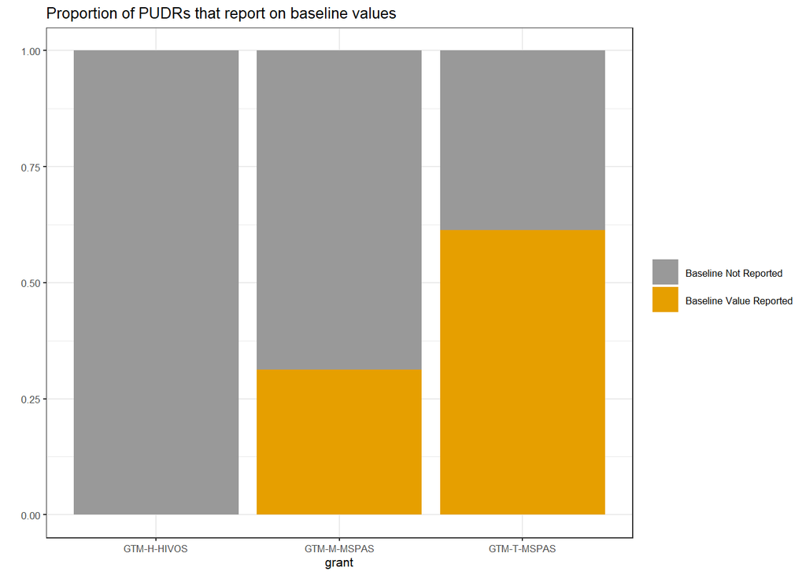

**The baseline value was not consistently provided in the different PUDRS. In some instances no baseline values were provided and in others more than half of the indicators had a baseline value included.**

In order to calculate the achievement of an Outcome Indicator for a given grant, it is necessary to have information on (1) the target that was originally set and (2) the result.

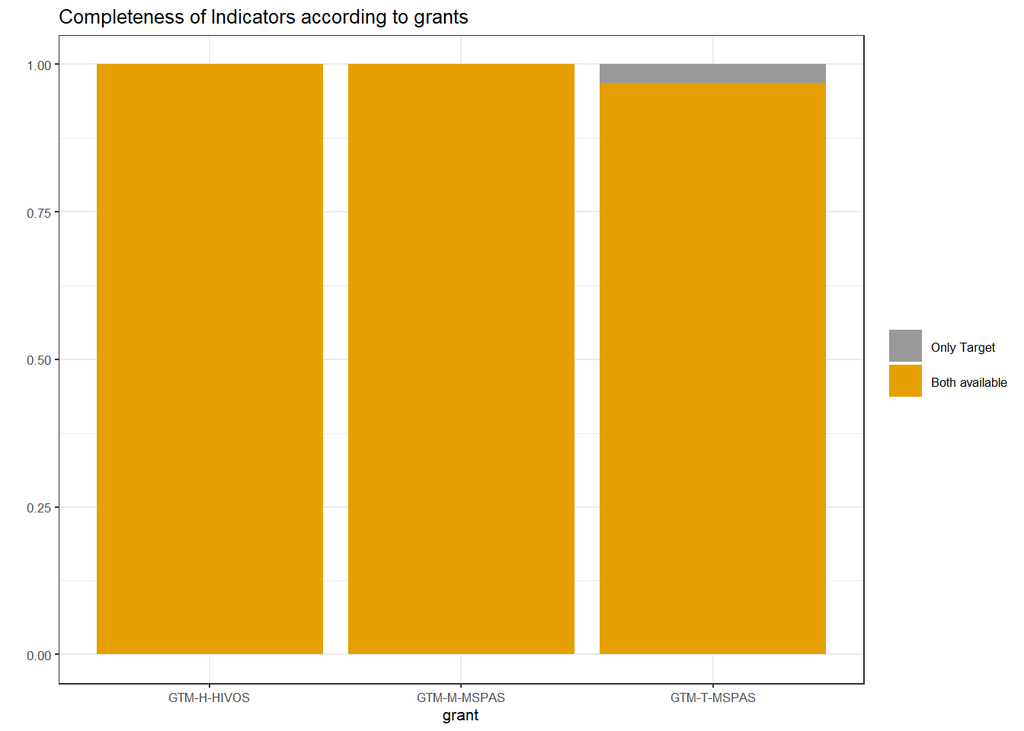

**Data was widely available on targets and results for all of the indicators in the grants.**

## 3. Data Sources

“Data Sources” are listed in the PUDR to indicate where information reported to the global fund came from. Examples of data sources include reports from the disease-specific National Programs, surveys such as the Demographic Health Survey (DHS), and Health Management Information systems such as DHIS2.

| Grant | Indicators | Different Sources between Baseline and Result |
| --- | --- | --- |
| GTM-M-MSPAS | 16 | 9 |
| GTM-T-MSPAS | 31 | 1 |
| GTM-H-HIVOS | 5 | 0 |

**The Malaria Dashboard/Information System was used to establish the baseline values, but various Reports and Surveys were used to provide updates.**

## 4. Grant Results based on most recent PUDRs

The “Achievement Ratio” is calculated in the PUDR to understand how close to the original target the Outcome Indicator result is. A value of 1.0 or greater means that the Indicator’s goal has been met or exceeded.

### 4.1 Malaria Grant

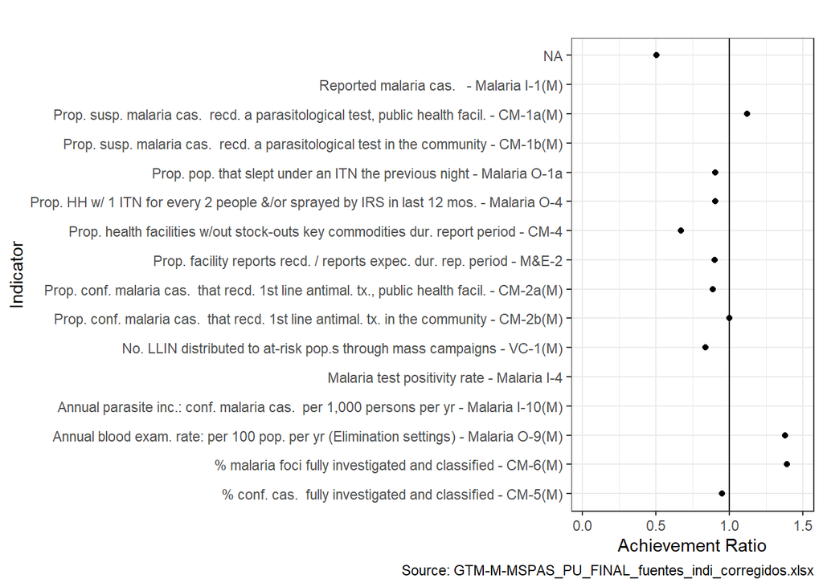

**The majority of indicators are close to the expected targets in the GTM-M-MSPAS Grant. Among the furthest from the targets is proportion of facilities without stock-outs of key commodities.**

### 4.2 TB Grant

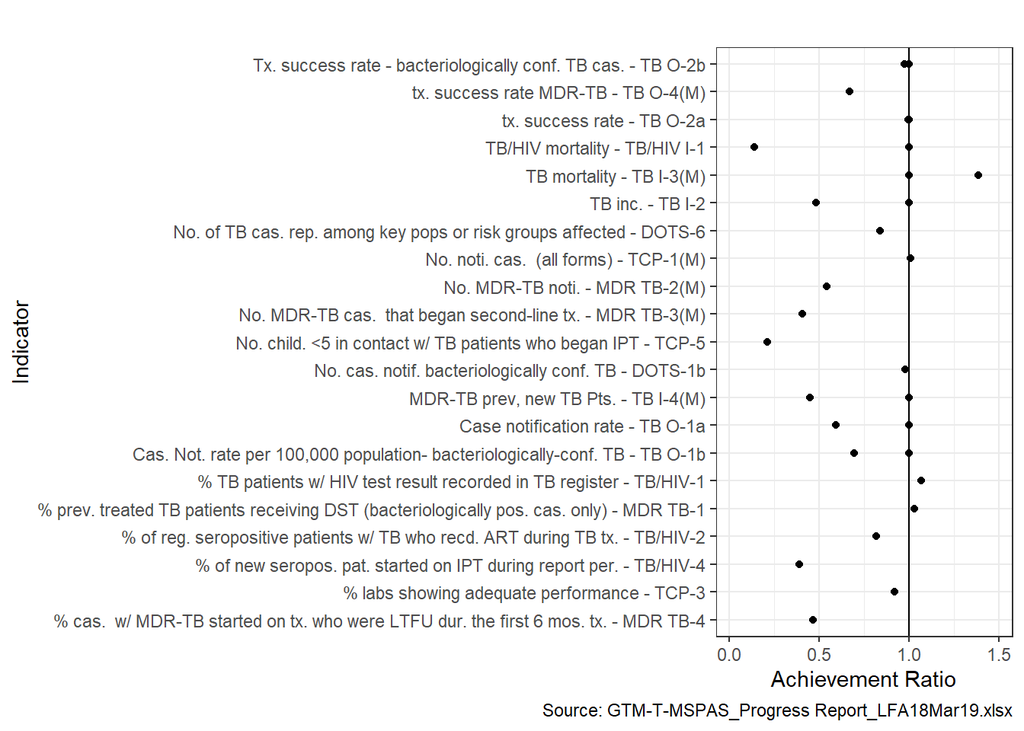

### 4.3 HIV Grant

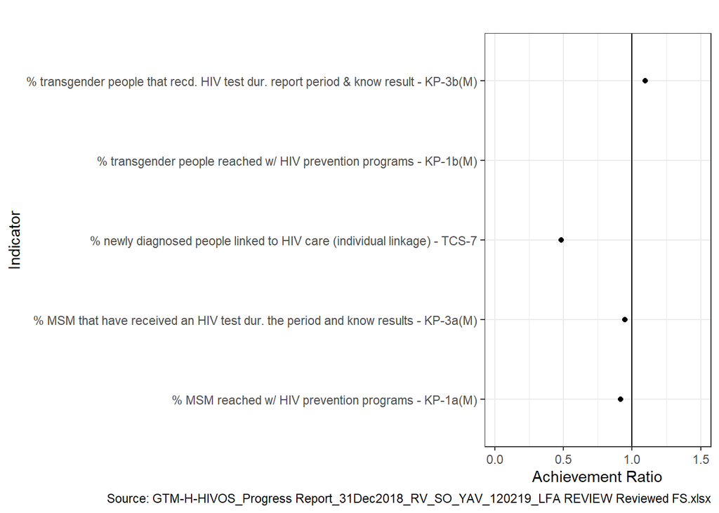

## 5. Agreement between PR, LFA

After each PUDR is submitted by the PR, the LFA will verify the results reported on the Indicators. In some cases they may revise the original values provided by the PR.

The most recent LFA-verified PUDRs for this analysis include the following:

| LFA Verified PUDR Files |
| --- |
| GTM-H-HIVOS_Progress Report_31Dec2018_RV_SO_YAV_120219_LFA REVIEW Reviewed FS.xlsx |
| GTM-T-MSPAS_Progress Report_LFA18Mar19.xlsx |

**They both refer to PUDRs sent in at the end of the second semester of 2018.**

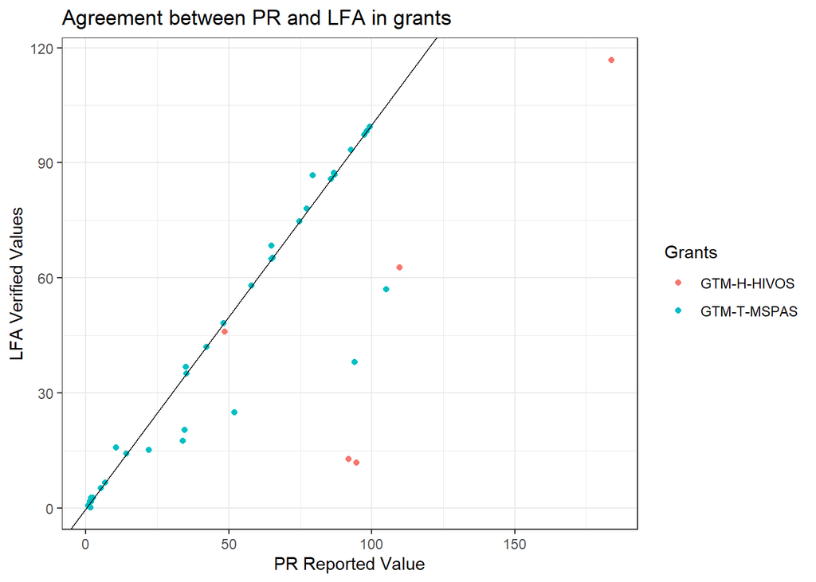

**There was a high level of agreement between the values reported by the PR and those verified by the GF LFA. In instances where the LFA did change the values they usually lowered the values that were reported.**

## 6. Results Over Time

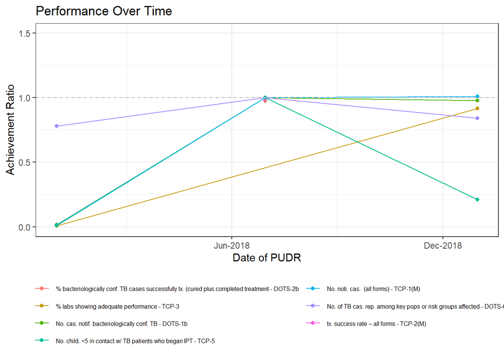

**There has been improvement in several of the impact and outcome indicators over time, although preventive treatment for children in contact with TB patients has been below target as of the most recent PUDR.**

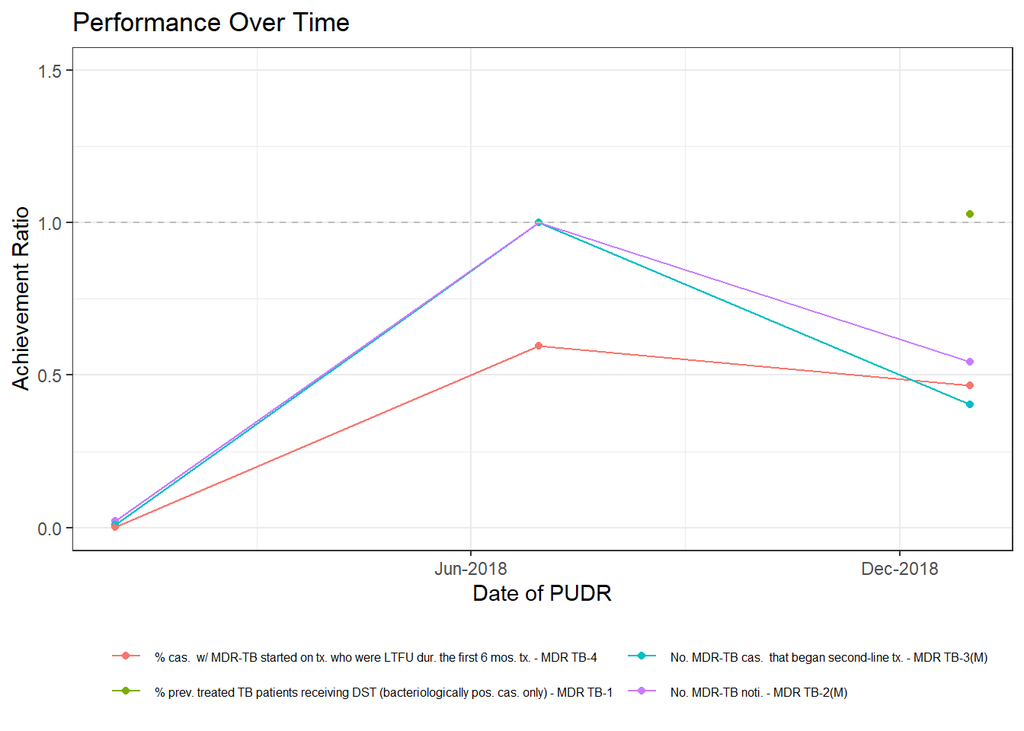